# EDA

Team

2024-12-08

## Loading our Data

```r
library(readr)
train <- read_csv("~/Desktop/15.072_AAE/Project/tabular_data/train.csv")
test <- read_csv("~/Desktop/15.072_AAE/Project/tabular_data/test.csv")
```

## Here we aim to show some exploratory data analysis to further understand the tabular data that we have. There is a great deal of missing data in these data sets, which makes the problem we aim to solve both interesting and difficult. Recall that the subjects/observations in the model are indeed humans. Human nature is unpredictable and often the information that we have on human subjects is sporadic. This data displays this uncertainty regarding human behavior.

```r
# Number of NA values in the training data:
total_NAs_train <- sum(is.na(train))
cat("Number of NAs in train: ", total_NAs_train, "\n")
```

```
## Number of NAs in train:  131717
```

```r
# Number of NA values in the testing data:
total_NAs_test <- sum(is.na(test))
cat("Number of NAs in test: ", total_NAs_test, "\n")
```

```
## Number of NAs in test:  590
```

```r
total_NAs <- total_NAs_test + total_NAs_train
cat("Total Number of NAs: ", total_NAs, "\n")
```

```
## Total Number of NAs:  132307
```

### There are a total of 132307 NA values in the data.

### We can now look at the number of NA values per column in this data.

```r
NAs_per_column_train <- colSums(is.na(train))

for (col_name in names(NAs_per_column_train)) {
  cat("Number of NAs in column", col_name, ":", NAs_per_column_train[col_name], "\n")
}
```

```
## Number of NAs in column id : 0
## Number of NAs in column Basic_Demos-Enroll_Season : 0
## Number of NAs in column Basic_Demos-Age : 0
## Number of NAs in column Basic_Demos-Sex : 0
## Number of NAs in column CGAS-Season : 1405
## Number of NAs in column CGAS-CGAS_Score : 1539
## Number of NAs in column Physical-Season : 650
## Number of NAs in column Physical-BMI : 938
## Number of NAs in column Physical-Height : 933
## Number of NAs in column Physical-Weight : 884
## Number of NAs in column Physical-Waist_Circumference : 3062
## Number of NAs in column Physical-Diastolic_BP : 1006
## Number of NAs in column Physical-HeartRate : 993
## Number of NAs in column Physical-Systolic_BP : 1006
## Number of NAs in column Fitness_Endurance-Season : 2652
## Number of NAs in column Fitness_Endurance-Max_Stage : 3217
## Number of NAs in column Fitness_Endurance-Time_Mins : 3220
## Number of NAs in column Fitness_Endurance-Time_Sec : 3220
## Number of NAs in column FGC-Season : 614
## Number of NAs in column FGC-FGC_CU : 1638
## Number of NAs in column FGC-FGC_CU_Zone : 1678
## Number of NAs in column FGC-FGC_GSND : 2886
## Number of NAs in column FGC-FGC_GSND_Zone : 2898
## Number of NAs in column FGC-FGC_GSD : 2886
## Number of NAs in column FGC-FGC_GSD_Zone : 2897
## Number of NAs in column FGC-FGC_PU : 1650
## Number of NAs in column FGC-FGC_PU_Zone : 1689
## Number of NAs in column FGC-FGC_SRL : 1655
## Number of NAs in column FGC-FGC_SRL_Zone : 1693
## Number of NAs in column FGC-FGC_SRR : 1653
## Number of NAs in column FGC-FGC_SRR_Zone : 1691
## Number of NAs in column FGC-FGC_TL : 1636
## Number of NAs in column FGC-FGC_TL_Zone : 1675
## Number of NAs in column BIA-Season : 1815
## Number of NAs in column BIA-BIA_Activity_Level_num : 1969
## Number of NAs in column BIA-BIA_BMC : 1969
## Number of NAs in column BIA-BIA_BMI : 1969
## Number of NAs in column BIA-BIA_BMR : 1969
## Number of NAs in column BIA-BIA_DEE : 1969
## Number of NAs in column BIA-BIA_ECW : 1969
```

[output cut: 27 more lines]

```
## Number of NAs in column PCIAT-PCIAT_13 : 1231
## Number of NAs in column PCIAT-PCIAT_14 : 1228
## Number of NAs in column PCIAT-PCIAT_15 : 1230
## Number of NAs in column PCIAT-PCIAT_16 : 1232
## Number of NAs in column PCIAT-PCIAT_17 : 1235
## Number of NAs in column PCIAT-PCIAT_18 : 1232
## Number of NAs in column PCIAT-PCIAT_19 : 1230
## Number of NAs in column PCIAT-PCIAT_20 : 1227
## Number of NAs in column PCIAT-PCIAT_Total : 1224
## Number of NAs in column SDS-Season : 1342
## Number of NAs in column SDS-SDS_Total_Raw : 1351
## Number of NAs in column SDS-SDS_Total_T : 1354
## Number of NAs in column PreInt_EduHx-Season : 420
## Number of NAs in column PreInt_EduHx-computerinternet_hoursday : 659
## Number of NAs in column sii : 1224
```

```r
NAs_per_column_train_df <- as.data.frame(NAs_per_column_train)

NAs_per_column_train_df
```

```
##                                        NAs_per_column_train
## id                                                        0
## Basic_Demos-Enroll_Season                                 0
## Basic_Demos-Age                                           0
## Basic_Demos-Sex                                           0
## CGAS-Season                                            1405
## CGAS-CGAS_Score                                        1539
## Physical-Season                                         650
## Physical-BMI                                            938
## Physical-Height                                         933
## Physical-Weight                                         884
## Physical-Waist_Circumference                           3062
## Physical-Diastolic_BP                                  1006
## Physical-HeartRate                                      993
## Physical-Systolic_BP                                   1006
## Fitness_Endurance-Season                               2652
## Fitness_Endurance-Max_Stage                            3217
## Fitness_Endurance-Time_Mins                            3220
## Fitness_Endurance-Time_Sec                             3220
## FGC-Season                                              614
## FGC-FGC_CU                                             1638
## FGC-FGC_CU_Zone                                        1678
## FGC-FGC_GSND                                           2886
## FGC-FGC_GSND_Zone                                      2898
## FGC-FGC_GSD                                            2886
## FGC-FGC_GSD_Zone                                       2897
## FGC-FGC_PU                                             1650
## FGC-FGC_PU_Zone                                        1689
## FGC-FGC_SRL                                            1655
## FGC-FGC_SRL_Zone                                       1693
## FGC-FGC_SRR                                            1653
## FGC-FGC_SRR_Zone                                       1691
## FGC-FGC_TL                                             1636
## FGC-FGC_TL_Zone                                        1675
## BIA-Season                                             1815
## BIA-BIA_Activity_Level_num                             1969
## BIA-BIA_BMC                                            1969
## BIA-BIA_BMI                                            1969
## BIA-BIA_BMR                                            1969
## BIA-BIA_DEE                                            1969
```

[output cut: 28 more lines]

```
## PCIAT-PCIAT_13                                         1231
## PCIAT-PCIAT_14                                         1228
## PCIAT-PCIAT_15                                         1230
## PCIAT-PCIAT_16                                         1232
## PCIAT-PCIAT_17                                         1235
## PCIAT-PCIAT_18                                         1232
## PCIAT-PCIAT_19                                         1230
## PCIAT-PCIAT_20                                         1227
## PCIAT-PCIAT_Total                                      1224
## SDS-Season                                             1342
## SDS-SDS_Total_Raw                                      1351
## SDS-SDS_Total_T                                        1354
## PreInt_EduHx-Season                                     420
## PreInt_EduHx-computerinternet_hoursday                  659
## sii                                                    1224
```

```r
NAs_per_column_test <- colSums(is.na(test))

for (col_name in names(NAs_per_column_test)) {
  cat("Number of NAs in column", col_name, ":", NAs_per_column_test[col_name], "\n")
}
```

```
## Number of NAs in column id : 0
## Number of NAs in column Basic_Demos-Enroll_Season : 0
## Number of NAs in column Basic_Demos-Age : 0
## Number of NAs in column Basic_Demos-Sex : 0
## Number of NAs in column CGAS-Season : 10
## Number of NAs in column CGAS-CGAS_Score : 12
## Number of NAs in column Physical-Season : 6
## Number of NAs in column Physical-BMI : 7
## Number of NAs in column Physical-Height : 7
## Number of NAs in column Physical-Weight : 7
## Number of NAs in column Physical-Waist_Circumference : 15
## Number of NAs in column Physical-Diastolic_BP : 9
## Number of NAs in column Physical-HeartRate : 8
## Number of NAs in column Physical-Systolic_BP : 9
## Number of NAs in column Fitness_Endurance-Season : 16
## Number of NAs in column Fitness_Endurance-Max_Stage : 17
## Number of NAs in column Fitness_Endurance-Time_Mins : 17
## Number of NAs in column Fitness_Endurance-Time_Sec : 17
## Number of NAs in column FGC-Season : 3
## Number of NAs in column FGC-FGC_CU : 7
## Number of NAs in column FGC-FGC_CU_Zone : 7
## Number of NAs in column FGC-FGC_GSND : 15
## Number of NAs in column FGC-FGC_GSND_Zone : 15
## Number of NAs in column FGC-FGC_GSD : 15
## Number of NAs in column FGC-FGC_GSD_Zone : 15
## Number of NAs in column FGC-FGC_PU : 7
## Number of NAs in column FGC-FGC_PU_Zone : 7
## Number of NAs in column FGC-FGC_SRL : 7
## Number of NAs in column FGC-FGC_SRL_Zone : 7
## Number of NAs in column FGC-FGC_SRR : 7
## Number of NAs in column FGC-FGC_SRR_Zone : 7
## Number of NAs in column FGC-FGC_TL : 7
## Number of NAs in column FGC-FGC_TL_Zone : 7
## Number of NAs in column BIA-Season : 12
## Number of NAs in column BIA-BIA_Activity_Level_num : 12
## Number of NAs in column BIA-BIA_BMC : 12
## Number of NAs in column BIA-BIA_BMI : 12
## Number of NAs in column BIA-BIA_BMR : 12
## Number of NAs in column BIA-BIA_DEE : 12
## Number of NAs in column BIA-BIA_ECW : 12
## Number of NAs in column BIA-BIA_FFM : 12
## Number of NAs in column BIA-BIA_FFMI : 12
## Number of NAs in column BIA-BIA_FMI : 12
## Number of NAs in column BIA-BIA_Fat : 12
## Number of NAs in column BIA-BIA_Frame_num : 12
## Number of NAs in column BIA-BIA_ICW : 12
## Number of NAs in column BIA-BIA_LDM : 12
## Number of NAs in column BIA-BIA_LST : 12
## Number of NAs in column BIA-BIA_SMM : 12
## Number of NAs in column BIA-BIA_TBW : 12
## Number of NAs in column PAQ_A-Season : 19
## Number of NAs in column PAQ_A-PAQ_A_Total : 19
## Number of NAs in column PAQ_C-Season : 11
## Number of NAs in column PAQ_C-PAQ_C_Total : 11
## Number of NAs in column SDS-Season : 10
## Number of NAs in column SDS-SDS_Total_Raw : 10
## Number of NAs in column SDS-SDS_Total_T : 10
## Number of NAs in column PreInt_EduHx-Season : 2
## Number of NAs in column PreInt_EduHx-computerinternet_hoursday : 4
```

```r
NAs_per_column_test_df <- as.data.frame(NAs_per_column_test)

NAs_per_column_test_df
```

```
##                                        NAs_per_column_test
## id                                                       0
## Basic_Demos-Enroll_Season                                0
## Basic_Demos-Age                                          0
## Basic_Demos-Sex                                          0
## CGAS-Season                                             10
## CGAS-CGAS_Score                                         12
## Physical-Season                                          6
## Physical-BMI                                             7
## Physical-Height                                          7
## Physical-Weight                                          7
## Physical-Waist_Circumference                            15
## Physical-Diastolic_BP                                    9
## Physical-HeartRate                                       8
## Physical-Systolic_BP                                     9
## Fitness_Endurance-Season                                16
## Fitness_Endurance-Max_Stage                             17
## Fitness_Endurance-Time_Mins                             17
## Fitness_Endurance-Time_Sec                              17
## FGC-Season                                               3
## FGC-FGC_CU                                               7
## FGC-FGC_CU_Zone                                          7
## FGC-FGC_GSND                                            15
## FGC-FGC_GSND_Zone                                       15
## FGC-FGC_GSD                                             15
## FGC-FGC_GSD_Zone                                        15
## FGC-FGC_PU                                               7
## FGC-FGC_PU_Zone                                          7
## FGC-FGC_SRL                                              7
## FGC-FGC_SRL_Zone                                         7
## FGC-FGC_SRR                                              7
## FGC-FGC_SRR_Zone                                         7
## FGC-FGC_TL                                               7
## FGC-FGC_TL_Zone                                          7
## BIA-Season                                              12
## BIA-BIA_Activity_Level_num                              12
## BIA-BIA_BMC                                             12
## BIA-BIA_BMI                                             12
## BIA-BIA_BMR                                             12
## BIA-BIA_DEE                                             12
## BIA-BIA_ECW                                             12
## BIA-BIA_FFM                                             12
## BIA-BIA_FFMI                                            12
## BIA-BIA_FMI                                             12
## BIA-BIA_Fat                                             12
## BIA-BIA_Frame_num                                       12
## BIA-BIA_ICW                                             12
## BIA-BIA_LDM                                             12
## BIA-BIA_LST                                             12
## BIA-BIA_SMM                                             12
## BIA-BIA_TBW                                             12
## PAQ_A-Season                                            19
## PAQ_A-PAQ_A_Total                                       19
## PAQ_C-Season                                            11
## PAQ_C-PAQ_C_Total                                       11
## SDS-Season                                              10
## SDS-SDS_Total_Raw                                       10
## SDS-SDS_Total_T                                         10
## PreInt_EduHx-Season                                      2
## PreInt_EduHx-computerinternet_hoursday                   4
```

### According to the output above, we can see that there is a substantial amount of NA values in nearly every column included in both the training and testing set of data relative to the total number of observations included in either data set. This high amount of missing data again is a major challenge, which is also a main point of this project. Data imputation could be important in order to appropriately predict the target variable, `ssi`. Furthermore, it is important to note that the target variable and the variables that are used to calculate the target variable, which begin with `PCIAT` all have a very high amount of NA values as well.

### Let’s try to glean some information about the target variable, `ssi`.

#### Box Plot series

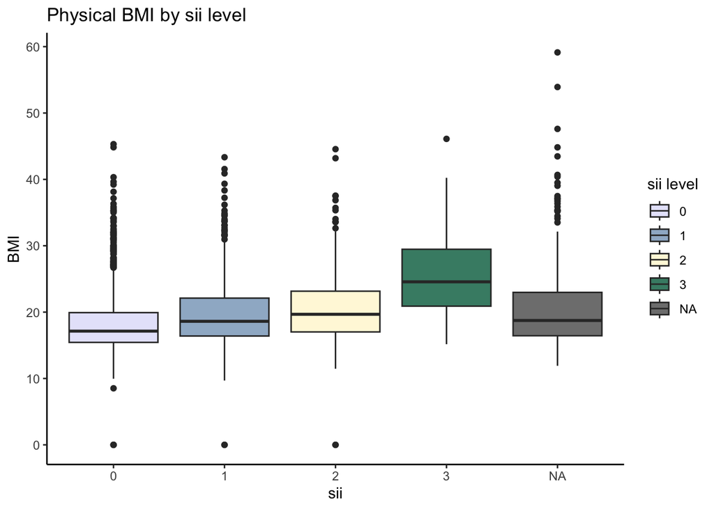

```r
train$sii <- as.factor(train$sii)

ggplot(train, aes(x=sii, y=`Physical-BMI`, fill=sii)) +
  scale_fill_manual(values = c("lavender","slategray3","cornsilk", "aquamarine4", "dimgrey")) +
  labs(title="Physical BMI by sii level",
       x="sii",
       y = "BMI")+ #labels such as titles, and axis labels.
  geom_boxplot(width=0.8)+ #sets the width of the boxplots used
  #coord_cartesian(ylim =  c(0, 2800))+: this is optional, and allows one to set the range on the y-axis
  theme_classic() +
  guides(fill=guide_legend(title = "sii level"))+
  scale_y_continuous(breaks = extended_breaks(n = 10)) #determines intervals on the y-axis
```

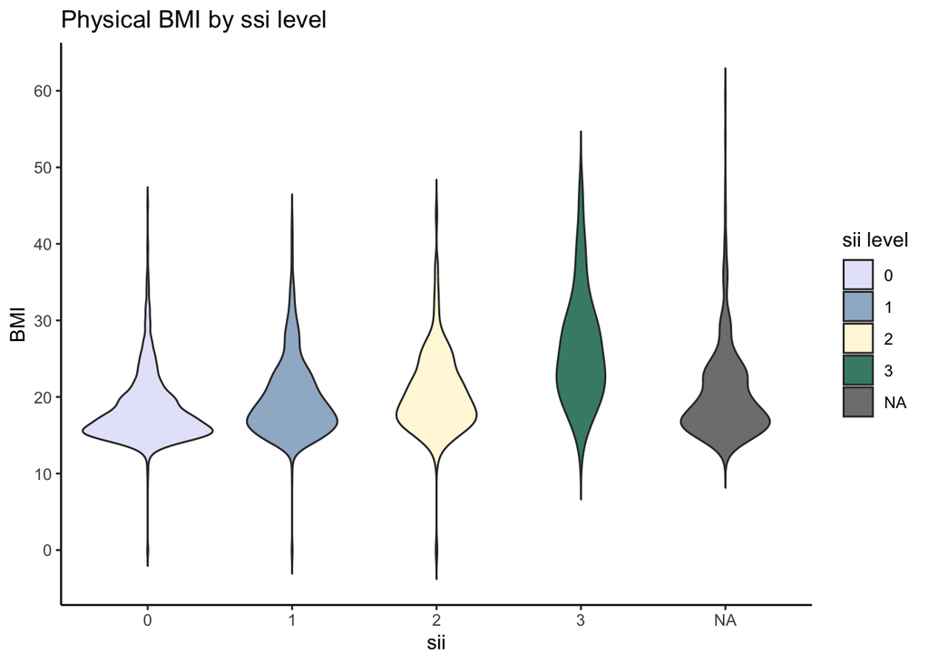

```r
#Violin Plot
ggplot(train, aes(x=sii, y=`Physical-BMI`, fill=sii)) +
  geom_violin(trim=FALSE)+
  scale_fill_manual(values = c("lavender","slategray3","cornsilk", "aquamarine4", "dimgrey")) + #set color values for your legend
  labs(title="Physical BMI by ssi level",
       x="sii",
       y = "BMI")+ #labels for the plot
  theme_classic() +
  guides(fill=guide_legend(title = "sii level"))+ #legend title
  scale_y_continuous(breaks = extended_breaks(n = 10)) #determines intervals on the y-axis
```

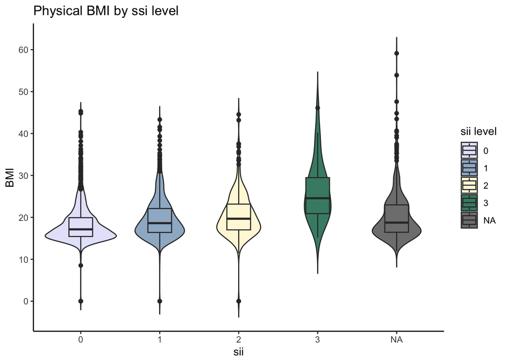

```r
# Violin and Boxplot Overlay
ggplot(train, aes(x=sii, y=`Physical-BMI`, fill=sii)) +
  geom_violin(trim=FALSE)+
  scale_fill_manual(values = c("lavender","slategray3","cornsilk", "aquamarine4", "dimgrey")) +
  labs(title="Physical BMI by ssi level",
       x="sii",
       y = "BMI")+ #labels such as titles, and axis labels.
  geom_boxplot(width=0.3)+ #sets the width of the boxplots used
  theme_classic() +
  guides(fill=guide_legend(title = "sii level"))+
  scale_y_continuous(breaks = extended_breaks(n = 10)) #determines intervals on the y-axis
```

```r
favstats(`Physical-BMI` ~ sii, data = train)
```

```
##   sii      min       Q1   median       Q3      max     mean       sd    n
## 1   0  0.00000 15.43632 17.13579 19.92165 45.30603 18.32955 4.450628 1467
## 2   1  0.00000 16.39930 18.61484 22.11088 43.33770 19.78944 5.045417  676
## 3   2  0.00000 17.01367 19.67327 23.15733 44.55410 20.50330 5.203170  351
## 4   3 15.16685 20.90048 24.56353 29.47007 46.10291 26.26632 7.084858   33
##   missing
## 1     127
## 2      54
## 3      27
## 4       1
```

### Recall that `sii` refers to “Severe Impairment Index” and higher values mean that an observation has more of a problem pertaining to problematic internet usage. It could be the case that the physical attributes of the observations can allow for inferences to be made regarding how problematic their internet usage might be. This plot tends to make some sense under a managerial lens as children who exercise less as a result of a high amount of interaction with the internet may develop higher BMIs. However, at this point, this is simply an inference, and should not be taken as a ground truth. Moving forward into modeling processes, we should however remember to consider the `Physical-BMI` as a potential variable of importance for predicting `sii`.

### We can create similar plots for all of the variables that pertain to physical features in the data:

```r
# Find all columns pertaining to physical features:

physical_features <- c("Physical-Height", "Physical-Weight",
                       "Physical-Waist_Circumference", "Physical-Diastolic_BP",
                       "Physical-HeartRate", "Physical-Systolic_BP")
```

```r
# Data preprocessing for plotting
df_physical_train <- train %>%
  dplyr::select(all_of(physical_features), sii) %>%
  pivot_longer(cols = all_of(physical_features),
               names_to = "Feature",
               values_to = "Value")  # Convert to long format for use with ggplot
```

```r
# Function to generate violin and box plots for the remaining physical features.
generate_plots <- function(data, feature) {
  ggplot(data %>% filter(Feature == feature), aes(x = factor(sii), y = Value, fill = factor(sii))) +
    geom_violin(trim = FALSE, alpha = 0.6) +  # Violin plot for density
    geom_boxplot(width = 0.1, outlier.size = 0.5, alpha = 0.8) +  # Box plot inside violin
    labs(title = paste("Distribution of", feature, "by sii Level"),
         x = "sii", y = feature, fill = "sii") +
    theme_minimal() +
    theme(plot.title = element_text(hjust = 0.5, size = 14))
}
```

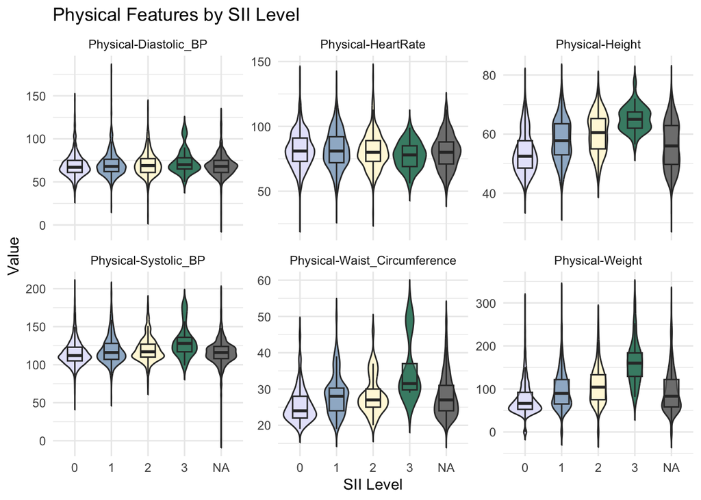

```r
ggplot(df_physical_train, aes(x = as.factor(sii), y = Value, fill = as.factor(sii))) +
  geom_violin(trim = FALSE) +
  geom_boxplot(width = 0.4, outlier.shape = NA, alpha = 0.5) +
  scale_fill_manual(values = c("lavender","slategray3","cornsilk", "aquamarine4", "dimgrey")) +
  facet_wrap(~Feature, scales = "free_y") +
  labs(title = "Physical Features by SII Level", x = "SII Level", y = "Value") +
  theme_minimal() +
  theme(legend.position = "none")
```

### The boxplots shown here can be interpreted in a very similar fashion as the box plot shown previously that relates `Physical-BMI` to `sii`. Overall, of the physical features included in the data set, it appears that the diastolic blood pressures, heart rates, and systolic blood pressures are fairly similar across all `sii` groups. However, we do see some differences in the distributions for weight, waist circumference, and BMI, which may be important features to consider when we move into modeling.

## We can now investigate the variable, `PreInt_EduHx-computerinternet_hoursday`, which is closely related to the target variable `sii`. `PreInt_EduHx-computerinternet_hoursday` refers to the number of hours that an observation spends using the compute or being engaged with the internet. This is a categorical variable where 0=Less than 1h/day, 1=Around 1h/day, 2=Around 2hs/day, and 3=More than 3hs/day.

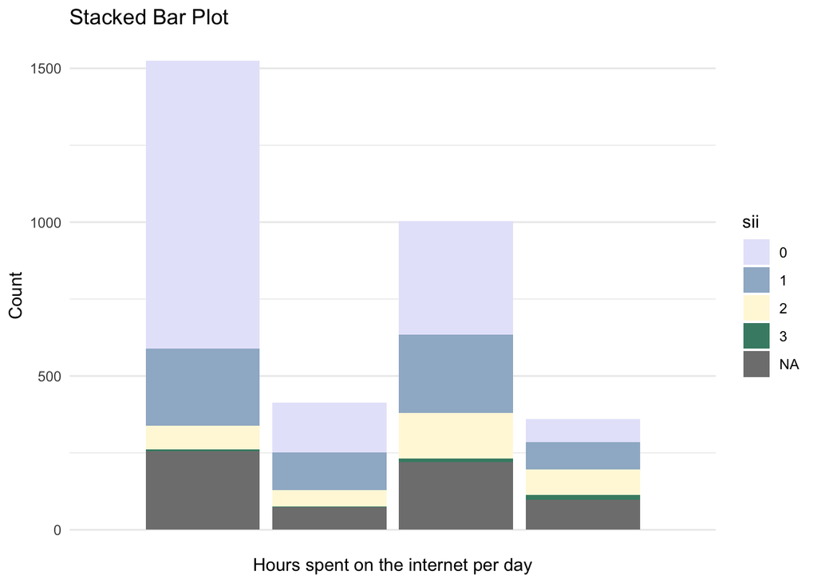

```r
x_true_labels <- c(
  "0" = "Less than 1 hour",
  "1" = "Around 1 hour",
  "2" = "Around 2 hours",
  "3" = "More than 3 hours"
)


plot <- ggplot(train, aes(x = `PreInt_EduHx-computerinternet_hoursday`,  fill = sii)) +
  geom_bar(position = "stack") +
  labs(
    title = "Stacked Bar Plot",
    x = "Hours spent on the internet per day",
    y = "Count",
    fill = "sii",
  ) + scale_fill_manual(values = c("lavender","slategray3","cornsilk", "aquamarine4", "dimgrey")) +
  scale_x_discrete(labels = x_true_labels)+
  theme(axis.text.x = element_text(angle = 90, vjust = 0.5, hjust=1))+ # Rotate x-axis
  theme_minimal()

plot + theme(axis.text.x = element_text(angle = 90, vjust = 0.5, hjust=1))
```

### According to the stacked bar plot, it is again noticeable that there are many NA values for `sii` across the various different levels of hours that a subject spends on the internet per day. However, we do notice that there is an abundance of observations that fall into a `sii` level of 0 that also use the internet for less than 1 hour per day. This observation is interesting and may be useful moving forward. It is reasonable to infer that a child that spends less time on the internet per day has less of a chance to develop bad habits pertaining to over usage and reliance on the internet. Again, thinking about the observations from our EDA under a managerial lens is important in moving to the next steps regarding what features may be important predictors of the `sii`, which is our target variable.

## Other important features to consider moving forward:

There is a wide array of features in the data set that pertain to various features regarding a child’s physical health and fitness. These features include information about a child’s test performance on a series of fitness tests as well information on a child’s bio electrical impedance analysis, which refers to body composition data.

Moving forward into the modeling process, we aim to use as many of the important features as possible in an effort to predict `sii`. It should be noted that from a managerial perspective it makes good sense to use all of the data included as these metrics largely give insight into a child’s physical health and fitness, which may allow us to make inferences on the child’s time spent using the internet. It follows that children who are more fit and healthy may be exercising more and spending less time interacting with the internet. However, the nature of this problem is inherently difficult because typically, information regarding problematic internet usage is self-reported. In this case, we aim to leverage physical fitness data as well, which is clearly measured and less susceptible to bias than self-reported data.